# PAC1 Análisis estadístico de microarrays Caso de estudio: “Arabidopsis degradome analysis from Tobacco rattle virus (TRV) infected plants” ([GEO:GSE106322](https://www.ncbi.nlm.nih.gov/geo/query/acc.cgi?acc=GSE106322))

Giannina Bambaren Capurro

# 1 Abstract

El virus *Tobacco rattle virus* (TRV en adelante) es un virus de la familia *Virgaviridae*, este virus ssRNA(+) utiliza como vector a los nemátodos para infectar plantas ornamentales principalmente. En este estudio se han infectado inflorencencias de *Arabidopsis thaliana* con TRV, de estas se obtuvieron para el análisis mediante microarrays de miRNAs cazado mediante el método de RLM-RACE (método descrito en: **Franco-Zorrilla et al. (2009)**). Mediante este estudio compararemos la expresion diferencial de genes de plantas infectadas y no infectadas.

# 2 Keyword

Arabidopsis thaliana, TRV, miRNAs, Gene Expresion, Microarrays

# 3 Objetivo

Este estudio consiste en el identificación de la expresión diferencial de genes de *Arabidopsis thaliana* después que sus inflorescencias fueran infectadas con el virus Tobacco rattle virus (TRV).

# 4 Materiales y métodos

Para el desarrolo de este caso de estudio, realizaremos un pipeline basado en el análisis de microarray mediante R y Bioconductor. Los pasos que seguiremos serán:

1. Lectura de datos sin procesar
2. Control de calidad
3. Normalización
4. Filtrado de genes
5. Selección de genes expresados diferencialmente
6. Comparación de listas seleccionadas
7. Análisis de importancia biológica

El código utilizado para este análisis se proporcionará en un repositorio de github[https://github.com/gb0406/pac1]

## 4.1 1. Librerias utilizadas en este estudio:

En este análisis utlizaremos las siguientes librerías y paquetes de R/Bioconductor que nos servirán de herramientas para estudio de este microarray:

```r
> require(AnnotationDbi)
> require(knitr)
> require(kableExtra)
> require(viridisLite)
> require(readr)
> require(oligo)
> require(Biobase)
> require(GEOquery)
> require(arrayQualityMetrics)
> require(genefilter)
> require(ath1121501.db)
> require(limma)
> require(ggplot2)
> require(gplots)
> source("https://raw.githubusercontent.com/uebvhir/UEB_PCA/master/UEB_plotPCA3.R")
> require(org.At.tair.db)
> require(clusterProfiler)
> require(enrichplot)
```

## 4.2 Diseño experimental

El experimento consiste en 3 réplicas biológicas de plantas infectadas con TRV y plantas inoculadas sin virus. Cada muestra de RNA se dividió en dos grupos: muestras marcadas con RNA ligadas (RLM-RACE) y no ligadas.Las muestras se obtuvieron por separado para la hibridación de microarrays Affymetrix ATH1.

## 4.3 Preparación de los datos

Para la lectura de los datos hemos creado un documento *targets.cvs*, el cual presenta el nombre de cada muestra además del grupo al que pertenece cada una.

Tenemos 12 muestras que pertenecen a 4 grupos, 3 réplicas biólogicas por grupo.

*Tabla 1: Datos ordenados por el grupo*

| Grupos | Frecuencia |
| --- | --- |
| Mock.non.ligated | 3 |
| Mock.RLM | 3 |
| TRV.non.ligated | 3 |
| TRV.RLM | 3 |

### 4.3.1 Lectura de los archivos en formato .Cell

Nos hemos descargado y descomprimido los celFiles desde GEO, utilizando su código de acceso: GSE106322, el archivo *“GSE106322_RAW.tar”* se encuentra en la sección **Suplementary file**.

Para leer y cargar los archivos celFiles utilizamos la librería `oligo`. La tabla **targets** creada nos servirá para asociar la información de esta tabla con los archivos CEL, a esto se le conoce como *ExpressionSet*.

Para ello utilizamos el paquete `Biobase::read.AnnotatedDataFrame`.

Guardaremos esta información en la variable *rawData*, ya que estos datos serán nuestros datos crudos (sin procesar) a analizar.

Tabla targets

|  | Group | Genotype | Treatment | ShortName |
| --- | --- | --- | --- | --- |
| GSM2835939_TRV_RLM_rep1.CEL | TRV.RLM | TRV | RLM | TRV_RLM_rep1 |
| GSM2835940_TRV_RLM_rep2.CEL | TRV.RLM | TRV | RLM | TRV_RLM_rep2 |
| GSM2835941_TRV_RLM_rep3.CEL | TRV.RLM | TRV | RLM | TRV_RLM_rep3 |
| GSM2835942_TRV_non_ligated_rep1.CEL | TRV.non.ligated | TRV | non_ligated | TRV_non_ligated_rep1 |
| GSM2835943_TRV_non_ligated_rep2.CEL | TRV.non.ligated | TRV | non_ligated | TRV_non_ligated_rep2 |
| GSM2835944_TRV_non_ligated_rep3.CEL | TRV.non.ligated | TRV | non_ligated | TRV_non_ligated_rep3 |
| GSM2835945_Mock_RLM_rep1.CEL | Mock.RLM | Mock | RLM | Mock_RLM_rep1 |
| GSM2835946_Mock_RLM_rep2.CEL | Mock.RLM | Mock | RLM | Mock_RLM_rep2 |
| GSM2835947_Mock_RLM_rep3.CEL | Mock.RLM | Mock | RLM | Mock_RLM_rep3 |
| GSM2835948_Mock_non_ligated_rep1.CEL | Mock.non.ligated | Mock | non_ligated | Mock_non_ligated_rep1 |
| GSM2835949_Mock_non_ligated_rep2.CEL | Mock.non.ligated | Mock | non_ligated | Mock_non_ligated_rep2 |
| GSM2835950_Mock_non_ligated_rep3.CEL | Mock.non.ligated | Mock | non_ligated | Mock_non_ligated_rep3 |

Información almacenada en nuestro *ExpressionSet*. Para hacer más digerible el análisis, en adelante las muestras se llamarán por su nombre corto, como se muestra en la Tabla 2.

```
ExpressionFeatureSet (storageMode: lockedEnvironment)
assayData: 1 features, 12 samples
  element names: exprs
protocolData
  rowNames: TRV_RLM_rep1 TRV_RLM_rep2 ... Mock_non_ligated_rep3 (12
    total)
  varLabels: exprs dates
  varMetadata: labelDescription channel
phenoData
  rowNames: TRV_RLM_rep1 TRV_RLM_rep2 ... Mock_non_ligated_rep3 (12
    total)
  varLabels: Group Genotype Treatment ShortName
  varMetadata: labelDescription channel
featureData: none
experimentData: use 'experimentData(object)'
Annotation: pd.ath1.121501
```

## 4.4 Control de calidad de los datos crudos

Para verificar la calidad de los datos crudos, utilizamos el paquete de Bioconductor `arrayQualityMetrics`. Este nos produce un serie de archivos que se guardarán en la carpeta *raWData_quality*, entre estos archivos se encuentra un resumen *index.html*, donde podemos ver lacalidad de nuestros datos, este analisis es de vital importancia ya que nos identifica la intesidad de los datos como además los outlier. Una mala calidad de los datos puede producirnos mucho ruido que no podrá ser resulto en la normalización de los datos.

Si uno de los datos está por encima se marca con un asterisco, ya que será un valor atípico. Si un grupo se marca más de tres veces tenemos que tener cuidado con este grupo, ya que empeora la calidad del experimento.

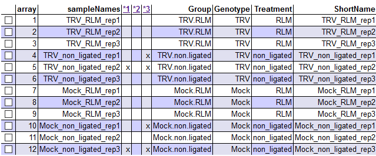

Figura 1: tabla de resumen del archivo index.html, producido por el paquete arrayQualityMetrics

```r
> # library(arrayQualityMetrics)
> #arrayQualityMetrics(rawData, outdir = "./Results/rawData_quality", force = T)
```

En nuestra gráfica de PCA podemos ver que la primera componente explica el 42.9% de la variabilidad total que se puede contribuir por la variabilidad entre estar ligado (muestras RLM) y no estar ligado, perola separación no es del todo clara.

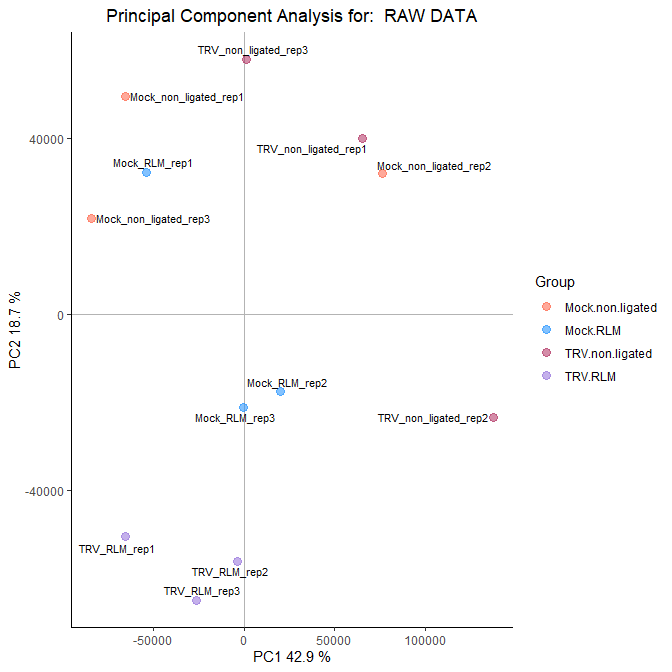

Figura 2: PCA de los datos crudos

Finalmente, veremos la distribución de la intensidad de los datos crudos mediante una gráfica boxplot. En la Figura 3 podemos ver que hay una variabilidad clara en la intensidad de estas muestras. En el caso del grupo de las plantas infectadas no ligadas veremos que existe una variación clara intragrupo, dada principalmente por la muestra 5.

Para intentar remediar la variablidad aportada por los datos vamos a normalizarlo a modo de tener datos con una distribición intragrupo homogénea, y que las diferencias que existan entre ellos sea explicadas por la variablidad entre grupos.

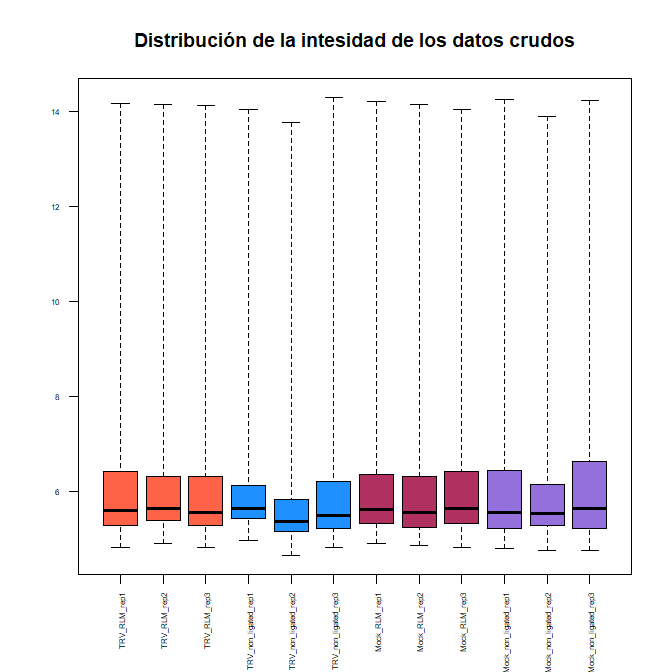

Figura 3: Boxplot de la distribución de la intesidad de los datos crudos

## 4.5 Normalización

Como hemos dicho anteriormente, con este proceso de *normalización* intentamos aminorar los sesgos por problemas técnicos, así conseguimos centrarnos en las diferencias biólogicas entre los grupos.

Para lleva a cabo la normalización de nuestros datos utilizaremos la función `rma` del paquete `oligo`, esta función realiza la corrección de fondo, normalizacion y resumen de los datos.

```r
> eset_rma = rma(rawData)
```

```
Background correcting
Normalizing
Calculating Expression
```

Ahora en el boxplot de los datos normalizados, podemos observar que la intensidad de las muestras es homogénea, todas las muestras parecen tener el mismo aspecto, de modo que podemos decir que los datos se han normalizado correctamente.

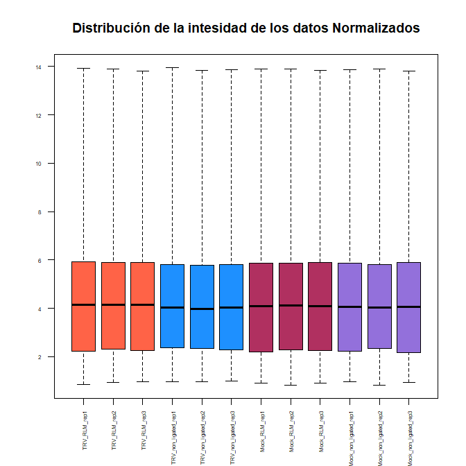

Figura 5: Boxplot de la distribución de la intesidad de los datos normalizados

### 4.5.1 Control de calidad de los datos normalizados

Vamos a volver a realizar el control de calidad de los datos, para ver si se ha disminuído la variabilidad intragrupo. En la figura 6 podemos observar que las muestras ya no nos señalan ningún “outlier”.

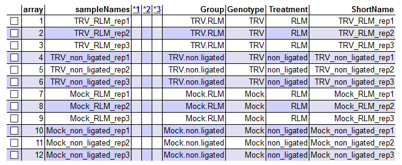

Figura 6: Análisis de calidad de los datos Normalizados

```r
> #arrayQualityMetrics(eset_rma, outdir = "./Results/normData_quality", force = T)
> knitr::include_graphics("./Results/normData_quality/metadata_norm.png")
```

En el siguiente análisis de PCA de datos normalizados que podemos ver la Figura 7, observamos que el porcentaje de explicación de la primera componente ha disminuído, y ha aumentado el porcentaje explicado por la segunda componente. En esta gráfica podemos observar un coherente agrupamiento de las muestas. Por un lado tener la primera componente que nos separía las muestas ligadas de las no ligas y por otro lado tendríamos que la segunda componente nos esta separando las muestras entre infectadas con TRV o sanas.

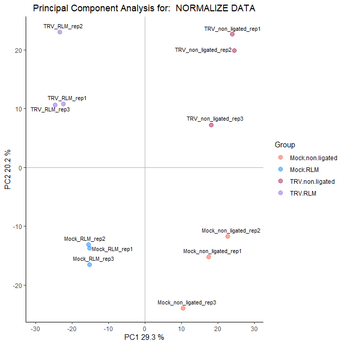

Figura 7: PCA de los datos normalizados

## 4.6 Filtraje de Genes no específico

Ahora vamos a filtrar los genes que deben su variabilidad a causas aleatorias, esto aumentará la potencia del análisis. Para realizar el filtraje no especifico utilizamos la función `nsFilter` de Bioconductor`genefilter`, además utilizaremos el paquete de anotaciones de la especie, en este caso utilizaremos el paquete `ath1121501.db` que utiliza los datos de anotación *Affymetrix Arabidopsis ATH1 Genome Array* Carlson (2016).

```
$numDupsRemoved
[1] 174

$numRemoved.ACCNUM
[1] 2475

$numLowVar
[1] 15112

$feature.exclude
[1] 12
```

## 4.7 Identificación de genes diferencialmente expresados

En este punto compararemos la diferente expresión de genes entre grupos. Es decir valoraremos la diferencia expresada entre los distintos grupos de las muestras.

En este experimente realizaremos una comparación de clases, donde el objetivo es señalar los genes que se expresan diferentemente entre los grupos, es decir, Genes expresados de forma diferente entre plantas sanas vs. infectadas o plantas ligadas vs. no ligadas.

Para el análisis estadístico de estos grupos utilizaremos el Modelo linear para microarray, este protocolo esta implementado en el paquete de Bioconductor `limma`.

### 4.7.1 Matriz de diseño

Para realizar el análisis basado en modelos lineales creamos una matriz de diseño donde asignamos a cada muestra el grupo al que pertenece, esta matriz presentará en nuestro caso 12 filas ya que tenemos 12 muestras y 4 colunmas que corresponden a los grupos. Si la muestra pertenece a un grupo se le asignará un *1*.

```
                      Mock.non.ligated Mock.RLM TRV.non.ligated TRV.RLM
TRV_RLM_rep1                         0        0               0       1
TRV_RLM_rep2                         0        0               0       1
TRV_RLM_rep3                         0        0               0       1
TRV_non_ligated_rep1                 0        0               1       0
TRV_non_ligated_rep2                 0        0               1       0
TRV_non_ligated_rep3                 0        0               1       0
Mock_RLM_rep1                        0        1               0       0
Mock_RLM_rep2                        0        1               0       0
Mock_RLM_rep3                        0        1               0       0
Mock_non_ligated_rep1                1        0               0       0
Mock_non_ligated_rep2                1        0               0       0
Mock_non_ligated_rep3                1        0               0       0
attr(,"assign")
[1] 1 1 1 1
attr(,"contrasts")
attr(,"contrasts")$Group
[1] "contr.treatment"
```

### 4.7.2 Matriz de contraste

Crearemos una matrix de contraste donde reflejaremos las comprareciones que realizaremos entre los grupos. Vamos a realizar 3 comparaciones:

- Efecto 1: **TRV.RLM - TRV.non.ligated**, plantas infectas con TRV compararemos entre las ligadas y las no ligadas.
- Efecto 2: **Mock.RLM - Mock.non.ligated**, comparación entre los grupos de plantas sanas, ligadas versus no ligadas.
- Interacción: **TRV.RLM - Mock.RLM**, buscamos observar el efecto de la interacción entre plantas sanas e infectadas que han sufrido el método de ligación RLM-RACE.

```
                  Contrasts
Levels             Efecto_1 Efecto_2 Interacion
  Mock.non.ligated        0       -1          0
  Mock.RLM                0        1         -1
  TRV.non.ligated        -1        0          0
  TRV.RLM                 1        0          1
```

## 4.8 Estimación de modelos y selección de genes

Realizamos la estimación del modelo linear con los grupos definidos en la matriz de diseño y los genes filtrados. Mediante la función `lmFit` del paquete `limma` calcularemos el ajuste lineal de cada gen.

```
[1] "MArrayLM"
attr(,"package")
[1] "limma"
```

### 4.8.1 Lista de expresión diferencias de genes por contraste

Para cada comparación vamos a realizar una lista de genes ordenados mediante su p-valor ajustado más pequeño, para evitar un gran número de falsos positvos utilizaremos la corrección de *False Discovery rate* (FDR) con el método de Benjamini y Hochberg (BH).

Las listas de genes la obtenemos mediante la función `topTable` que extrae los genes mejor clasificados del ajuste linear anteriormente realizado.

Cada lista presenta las siguientes variables:

- `logFC`: diferencia media entre grupos.
- `AveExpr`: expresión promedio de todos los genes en la comparación.
- `t`: estadística t moderada (estadística similar a la prueba t para la comparación).
- `P.Value`: prueba p - valor.
- `adj.P.Val`: valor p ajustado después de BH
- `B`: estadística B: probabilidades de log posteriores del gen de ser versus no ser diferencial expresado.

Mostraremos los 5 primeros valores de cada tabla, estos serán entonces, los mejores clasificados de cada constraste. En este caso las listas estan anotadas por el código de sonda del producto Affymetrix.

Efecto 1: Plantas infectadas TRV ligadas vs. no ligadas

|  | logFC | AveExpr | t | P.Value | adj.P.Val | B |
| --- | --- | --- | --- | --- | --- | --- |
| 244965_at | 4.091715 | 4.036087 | 24.22249 | 0 | 0 | 27.57304 |
| 265847_at | 3.741039 | 6.330452 | 23.57871 | 0 | 0 | 27.12664 |
| 244961_at | 3.176150 | 5.309869 | 16.14899 | 0 | 0 | 20.51021 |
| 244932_at | 2.695652 | 6.182683 | 15.88124 | 0 | 0 | 20.20867 |
| 244970_at | 3.168661 | 5.723833 | 14.99382 | 0 | 0 | 19.16953 |

Efecto 2: Plantas Sanas ligadas vs. no ligadas

|  | logFC | AveExpr | t | P.Value | adj.P.Val | B |
| --- | --- | --- | --- | --- | --- | --- |
| 265847_at | 3.817864 | 6.330452 | 24.06291 | 0 | 0 | 27.28660 |
| 244965_at | 3.589873 | 4.036087 | 21.25164 | 0 | 0 | 25.22907 |
| 257323_at | 3.142714 | 3.474627 | 15.33818 | 0 | 0 | 19.52014 |
| 244938_at | 2.519717 | 6.036579 | 14.37829 | 0 | 0 | 18.36224 |
| 244961_at | 2.679136 | 5.309869 | 13.62194 | 0 | 0 | 17.39323 |

Interacción: Plantas ligadas Sanas vs. Infectadas

|  | logFC | AveExpr | t | P.Value | adj.P.Val | B |
| --- | --- | --- | --- | --- | --- | --- |
| 248676_at | -2.253205 | 3.625827 | -12.162636 | 0e+00 | 0.0000003 | 14.588596 |
| 251722_at | -1.339462 | 5.186338 | -8.582626 | 0e+00 | 0.0000614 | 9.180679 |
| 263515_at | 1.787671 | 6.625878 | 8.370710 | 0e+00 | 0.0000619 | 8.803443 |
| 254770_at | -1.675301 | 7.002443 | -7.968819 | 1e-07 | 0.0001035 | 8.069051 |
| 255284_at | -1.524955 | 5.757289 | -7.477815 | 2e-07 | 0.0002071 | 7.137877 |

### 4.8.2 Anotación de los resultados

De las lista de clasificación que hemos obtenido de nuestros contrastes que estan identificadas mediante las sondas, vamos darle “nombre” a estos códigos de Affymetrix con los genes que le corresponden. Para ello utilizamos la función `annotatedTopTable` que se basa en el uso del paquete de anotación, que para este estudio es `ath1121501.db` y la lista de sondas ordenadas por p-valor realizadas anteriormente.

La información que relacionaremos con da sonda serán:

- *“SYMBOL”*: Símbolo del nombre del gen
- *“GO”*: identificador GO del repositorio Gene Ontology
- *“GENENAME”*: Nombre completo del gen

Finalmente guardaremos las tablas de anotación en archivos “.csv”

```r
>  annotatedTopTable <- function(topTab, anotPackage){
+    topTab <- cbind(PROBEID=rownames(topTab), topTab)
+    myProbes <- rownames(topTab)
+    thePackage <- eval(parse(text = anotPackage))
+    geneAnots <- AnnotationDbi::select(thePackage,
+                 myProbes, c("SYMBOL", "GO", "GENENAME"))
+    annotatedTopTab<- merge(x=geneAnots, y=topTab,
+                     by.x="PROBEID", by.y="PROBEID")
+    return(annotatedTopTab)
+ }
```

Tabla de anotación Efecto 1

| PROBEID | SYMBOL | GO | EVIDENCE | ONTOLOGY | GENENAME | logFC | AveExpr | t | P.Value | adj.P.Val | B |
| --- | --- | --- | --- | --- | --- | --- | --- | --- | --- | --- | --- |
| 244901_at | ORF25 | GO:0000276 | IDA | CC | encodes a plant b subunit of mitochondrial ATP synthase based on structural similarity and the presence in the F(0) complex. | 1.232369 | 4.073107 | 5.657 | 1.25e-05 | 0.0004963 | 3.157762 |
| 244901_at | ORF25 | GO:0005739 | IDA | CC | encodes a plant b subunit of mitochondrial ATP synthase based on structural similarity and the presence in the F(0) complex. | 1.232369 | 4.073107 | 5.657 | 1.25e-05 | 0.0004963 | 3.157762 |

Tabla de anotación Efecto 2

| PROBEID | SYMBOL | GO | EVIDENCE | ONTOLOGY | GENENAME | logFC | AveExpr | t | P.Value | adj.P.Val | B |
| --- | --- | --- | --- | --- | --- | --- | --- | --- | --- | --- | --- |
| 244901_at | ORF25 | GO:0000276 | IDA | CC | encodes a plant b subunit of mitochondrial ATP synthase based on structural similarity and the presence in the F(0) complex. | 0.9960036 | 4.073107 | 4.571999 | 0.0001622 | 0.005636 | 0.6540416 |
| 244901_at | ORF25 | GO:0005739 | IDA | CC | encodes a plant b subunit of mitochondrial ATP synthase based on structural similarity and the presence in the F(0) complex. | 0.9960036 | 4.073107 | 4.571999 | 0.0001622 | 0.005636 | 0.6540416 |

Tabla de anotación de la interaccón

| PROBEID | SYMBOL | GO | EVIDENCE | ONTOLOGY | GENENAME | logFC | AveExpr | t | P.Value | adj.P.Val | B |
| --- | --- | --- | --- | --- | --- | --- | --- | --- | --- | --- | --- |
| 244901_at | ORF25 | GO:0000276 | IDA | CC | encodes a plant b subunit of mitochondrial ATP synthase based on structural similarity and the presence in the F(0) complex. | -0.2530985 | 4.073107 | -1.161809 | 0.2582322 | 0.4633397 | -5.68478 |
| 244901_at | ORF25 | GO:0005739 | IDA | CC | encodes a plant b subunit of mitochondrial ATP synthase based on structural similarity and the presence in the F(0) complex. | -0.2530985 | 4.073107 | -1.161809 | 0.2582322 | 0.4633397 | -5.68478 |

## 4.9 Expresión diferencial

### 4.9.1 Volcano plot

Utilizaremos un *Volcanoplot* para observar la expresión diferencial global. El Volcanoplot es una gráfica estadística utilziada ampliamente que evalúa la magnitud del “fold change” (M, impacto biólogico del cambio) con la significación estadística de cada gen (p-valor). Por un lado, en el eje vertical tenemos -log(pvalor) y la dispersión de la función M en el eje horizontal. Los p-valores más significativos estarán en la parte superior de la gráfica. Los genes *Up y down regulated* se encuentran de forma simétrica respecto al eje vertical, donde M=0. Con lo cual nos interesa mirar los genes que se encuentran en la parte superior de la gráfica Smyth, Yang, and Speed (2003).

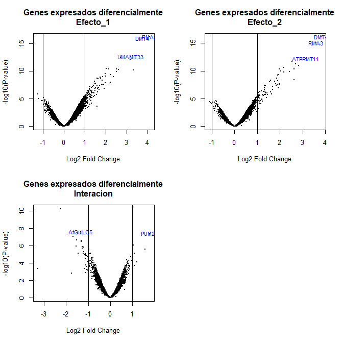

Figura 8: Volcano plot

### 4.9.2 Comparaciones múltiples

En este apartado intentaremos rescatar los genes seleccionados en cada comparación posteriormente lo repsentaremos en un diagrama de Venn. Estas dos funciones se encuentran dentro del paquete `limma` que cuenta los genes que han sido seleccionados por su relevancia biológica.

La selección se hace mediante el criterio FDR, donde se clasificarán valores de FDR

- +1 : up-regulated
- 0 : no significativo
- -1 : down.regulated

```
       Efecto_1 Efecto_2 Interacion
Down          4        3         32
NotSig     4898     4960       4998
Up          135       74          7
```

Podemos ver que muchos de los genes seleccionados en los contrastes no presentan significación biológica. A pesar de ellos encontramos genes up o down regulated seleccionados en cada constraste.

### 4.9.3 Diagrama de Venn

En la Figura 9 muestra cuántos de estos genes son compartidos por una o más comparaciones. En nuestro caso podemos ver que entre el efecto 1 y el efecto 2 se comparten 64 genes miéntras que se comparte poco con la interacción.

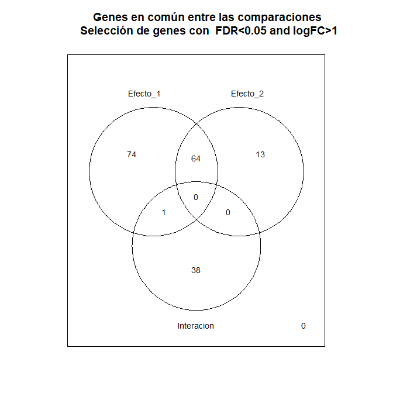

Figura 9: Diagrama de Venn

### 4.9.4 Heatmap

Con un heatmap podemos observar los genes que han sido seleccionados diferencialmente, mediante los colores expresados en el heatmap podemos diferencias si un gen esta up o down regulated para un grupo.

En el heatmap se representan los genes mediante su simbolo en las filas y los grupos y muestra al que pertenece cada gen en las columnas.

Vamos a representar un heatmap sin agrupamiento mediante clustering y otro con agrupamiento con cluster, de esta forma veremos que los genes se agruparan de diferente forma.

En la Figura 10 observamos que la mayoría de los genes en los grupos TRV_RLM y Mock_RLM, es decir, de plantas con tratamiento de ligación RLM-RACE se encuentra *up-regulated* respecto a las plantas que no presetan ligación (grupos TRV_non_ligated y Mock_non_ligated). En general las muestas presentan una señal homogénea intragrupo.

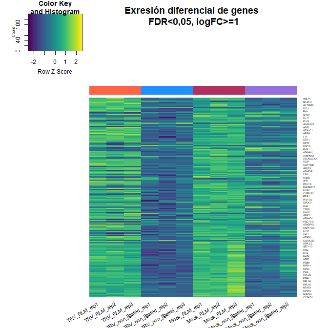

Figura 10: Heatmap de genes expresados diferencialmente sin agrupamiento

En la Figura 11 podemos ver que la distribución ahora es diferente a la anterior ya que los genes ahora se han forzado a agruparse por su similitud entre ellos.

Ahora en el heatmap se han agrupado las muestas no ligadas a la izquierda y las ligadas (RLM-RACE) a la derecha. Como veíamos en la figura anterior los genes de las muestras no ligadas en su mayoría se encuentran down-regulated mientras que los ligados se encuentran up-regulated. Salvo algunos grupos de genes de las plantas infectadas ligadas (TRV_RLM) que se encuentran down-regulated igual que las plantas mock ligadas. Los mismos pasa en el caso de las muestras no ligadas, ya que presentan un grupo de genes que se encuentran up-regulated tanto en plantas sanas como infectadas.

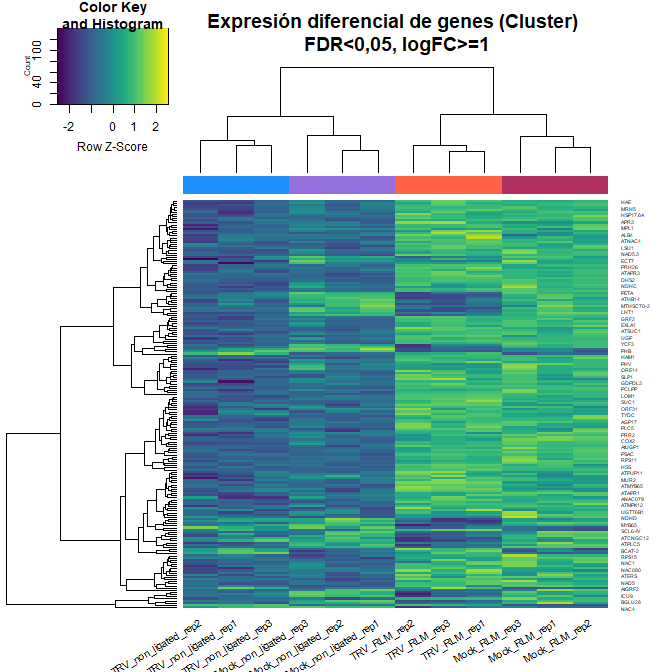

Figura 11: Heatmap de genes expresados diferencialmente agrupados por similitud

## 4.10 Análisis de significación biológica (“Gene Enrichment Analysis”)

Para realizar el análisis GEO, primero seleccionaremos la lista de anotaciones creada anteriormente, que contienen los genes seleccionados en cada anotación. Entonces de cada lista se comparará si los procesos biológicos en los que interviene cada conjunto de genes tienen una relación entre sí. Es decir, si en una comparación los genes seleccionados todos ellos relacionados en un proceso biológico como la división celular, etc. Esto nos daría pistas para entender las vías implicadas en cada grupo experimental.

Para este tipo de análisis de enriquecimiento utilizaremos el paquete de Bioconductor CLusterProfiler Yu et al. (2012). Este paquete nos permite realizar análisis de enriquecimiento de conjuntos de genes de muchas ontologías. En nuestro caso utilizamos el paquete de anotación para **Arabidopsis thaliana** de Bioconductor `org.At.tair.db`.

Los pasos que seguiremos para el análisis GEO serán:

```r
> listOfTables <- list(TRV =topTab_TRV ,
+                      Mock = topTab_Mock,
+                      INT = topTab_INT)
> listOfSelected <- list()
> for (i in 1:length(listOfTables)){
+   topTab <- listOfTables[[i]]
+   whichGenes<-topTab["adj.P.Val"]<0.15
+   selectedIDs <- rownames(topTab)[whichGenes]
+   GOIDs<- select(ath1121501.db, selectedIDs, c("SYMBOL"))
+   GOIDs <- GOIDs$SYMBOL
+   listOfSelected[[i]] <- GOIDs
+   names(listOfSelected)[i] <- names(listOfTables)[i]
+   }
> sapply(listOfSelected, length)
```

```
 TRV Mock  INT
3625 2316 1830
```

Podemos ver que cada comparación tiene gran cantidad de genes seleccionados (FDR<0.15), estos los utilizaremos para elaborar el análisis GEO. Tenemos que tener en cuentra que eliminaremos los valores nulos que puede tener la variable ENTREZID.

Guardaremos los resultados obtenido mediante CLUSTERprofile mediante tablas tipo archivo “.csv” y los gráfico en formato “.png”

```r
> for (i in 1:3){
+   comparison <- comparisonsNames[i]
+ gene.df <- bitr(na.omit(listOfData[[i]]), fromType = "SYMBOL",
+         toType = c("SYMBOL","GO", "ENTREZID","GENENAME"),
+         OrgDb = org.At.tair.db)
+ en_id<-na.omit(gene.df$ENTREZID)
+ #en_id<-gene.df$ENTREZID
+ enrich.result <- enrichGO(gene= en_id,
+                 OrgDb         = org.At.tair.db,
+                 keyType       = 'ENTREZID',
+                 ont           = "ALL",
+                 pAdjustMethod = "BH",
+                 pvalueCutoff  = 0.05,
+                 qvalueCutoff  = 0.2)
+ write.csv(as.data.frame(enrich.result),
+ file =paste0("./Results/cluster/","CLUSTER_Results_",comparison,".csv"),
+ row.names = FALSE)
+ png(file=paste0("./Results/cluster/","CLUSTER_Barplot_",comparison,".png"),
+      width = 1080, height = 1080, units = 'px')
+ print(barplot(enrich.result, showCategory = 15, font.size = 14,
+     title = paste0("Cluster Profile Analysis for ", comparison,". Barplot")))
+ dev.off()
+ png(file = paste0("./Results/cluster/","CLUSTER_cnetplot_",comparison,".png"),
+ width = 1080, height = 1080, units = 'px')
+ print(cnetplot(enrich.result, categorySize = "geneNum", schowCategory = 15,
+                vertex.label.cex = 0.75))
+ dev.off()
+ png(file=paste0("./Results/cluster/","CLUSTER_emapplot_",comparison,".png"),
+      width = 1080, height = 1080, units = 'px')
+ print(emapplot(enrich.result, pie_scale=1,layout="kk", font.size = 24,
+     title = paste0("Cluster Profile Analysis for ", comparison,". emapplot")))
+ dev.off()
+ }
```

Hemos creado diferentes tipos de gráficos que nos permiten visualizar de forma más simple el análisis GEO.

En las siguientes tablas podemos observar, los términos GO (Gene Ontology) relacionados con cada grupo de genes. La ontología puede ser de tres tipos: *BP* Biological process, *MF* Molecular Function y *CC* Cellular component. También encontramos una breve descripción del término GO, además *GeneRatio* nos indica la cantidad de genes relacionados con este término GO.

Análisis GEO plantas infectadas TRV

| ONTOLOGY | ID | Description | GeneRatio | BgRatio | pvalue |
| --- | --- | --- | --- | --- | --- |
| BP | GO:0009828 | plant-type cell wall loosening | 35/1251 | 35/20450 | 2.15724068906819e-43 |
| BP | GO:0009825 | multidimensional cell growth | 48/1251 | 111/20450 | 4.06006539961132e-29 |
| BP | GO:0009831 | plant-type cell wall modification involved in multidimensional cell growth | 24/1251 | 26/20450 | 1.76714110813702e-27 |
| BP | GO:0042547 | cell wall modification involved in multidimensional cell growth | 24/1251 | 28/20450 | 9.88614086715962e-26 |

Análisis GEO para plantas sanas

|  | ONTOLOGY | ID | Description | GeneRatio | BgRatio | pvalue |
| --- | --- | --- | --- | --- | --- | --- |
| 15 | BP | GO:0007389 | pattern specification process | 39/836 | 347/20450 | 0e+00 |
| 16 | BP | GO:0009555 | pollen development | 37/836 | 323/20450 | 0e+00 |
| 17 | BP | GO:0090626 | plant epidermis morphogenesis | 35/836 | 298/20450 | 0e+00 |
| 18 | BP | GO:0010014 | meristem initiation | 25/836 | 171/20450 | 0e+00 |
| 19 | BP | GO:0006631 | fatty acid metabolic process | 42/836 | 422/20450 | 1e-07 |

Análisis GEO para la interacción

|  | ONTOLOGY | ID | Description | GeneRatio | BgRatio | pvalue |
| --- | --- | --- | --- | --- | --- | --- |
| 50 | BP | GO:0016125 | sterol metabolic process | 16/638 | 171/20450 | 9.41871355067961e-05 |
| 51 | BP | GO:0042440 | pigment metabolic process | 25/638 | 346/20450 | 9.50495924599956e-05 |
| 52 | BP | GO:0000904 | cell morphogenesis involved in differentiation | 29/638 | 431/20450 | 9.61579525549442e-05 |
| 53 | BP | GO:0009991 | response to extracellular stimulus | 26/638 | 372/20450 | 0.000119073619544649 |
| 54 | BP | GO:0006972 | hyperosmotic response | 20/638 | 250/20450 | 0.000120902555049983 |

Un de las formas visuales que tenemos para observar este análisis es mediante gráficas. En nuestro caso hemos seleccionado tres tipos de gráficas: *Barplot*,*Cnetplot* y *Emapplot*

En una gráfica de barplot podemos ver un diagrama de barras, donde las barras represetan un término GO y el tamaño de la barra dependerá de la cantidad de genes que este término contenga, el color de la barra representan el p-valor de enrequecimiento. Este gráfico solo representa los término GO más significaticos en el análisis.

El ejemplo que mostramos, pertenece al barplot para la interración, es decir plantas infectadas vs. plantas sanas con tratamiento RLM-RACE. En este podemos ver que los genes más abundanten entre estos dos grupos son los que estan relacionados con la biogenesis y organización de la pared celular (plant-type cell wall organization or biogenesis).

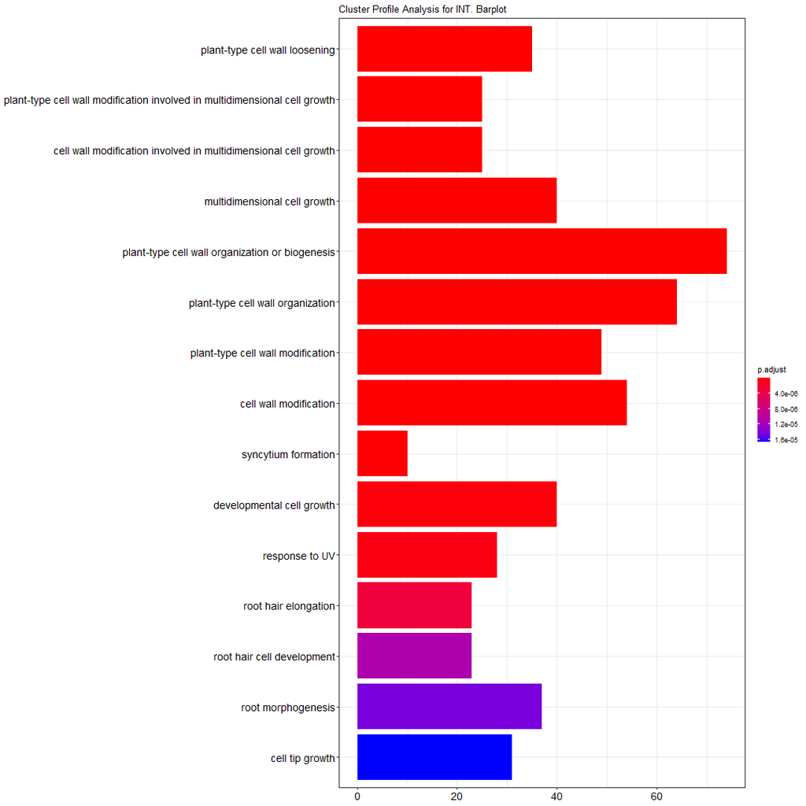

Figura 12: Barplot para plantas sanas vs. infectadas ligadas

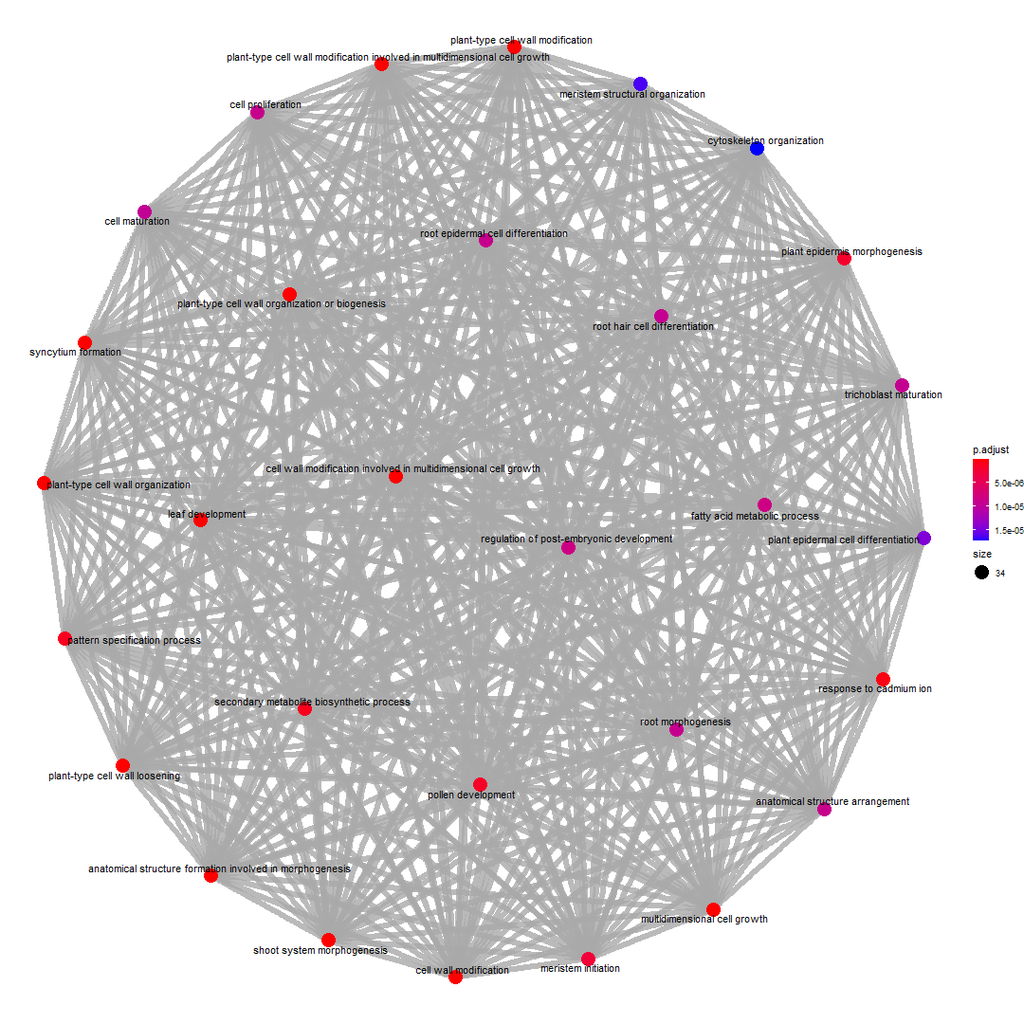

Figura 13: Emapplot para plantas sanas

Finalmente, el gráfico cnetplot, representa la relación del término GO (concepto bióligico) con los genes que lo contienen. Los genes estan representados su identificador ENTREZID numérico. En este caso mostraremos el gráfico cnetplot para plantas infectadas ligadas y no ligadas.

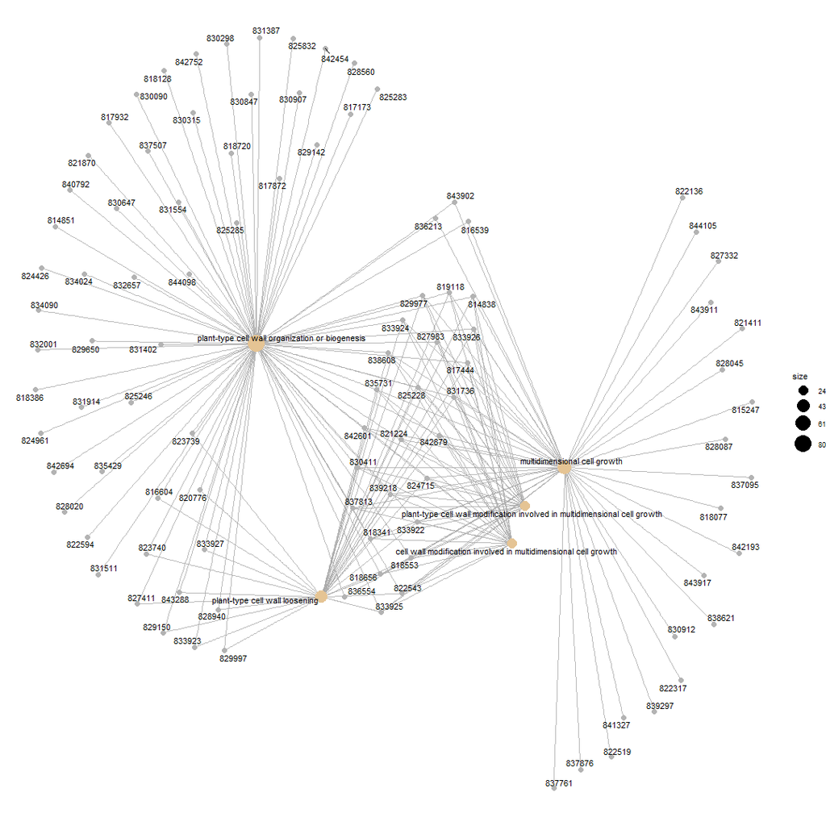

# 5 Resultados

De este análisis se han obtenido una serie de archivos que servirán para encontrar la relación existenten génica existente entre las plantas infectadas con el virus TRV respecto a las que no estan infectadas. Además, también puede ser de gran interés que algunas muestras hayan sido tratadas mnediante RLM-RACE y otras no.

Parece que existe una serie de mecanismos que se ponen en marcha en las plantas que han sufrido la ligación. Como hemos observado en la Figura 11, existe un clara diferenciación de genes que estan up-regulated cuando están ligados y down cuando estan no ligados. No hay una clara diferenciación génica entre las plantas infectadas y no infectadas.

# 6 Discusión

La expresión de un gen depende de muchos factores (que transcrito se expresa, vida media del RNA mensajero, traducción, modificación,etc). En el análisis de microarray podemos ver como se comportan cientos de genes de nuestras muestras e intentar llegar a una conclusión biólogica a partir de ello. Para ellos tenemos que análisis los datos de la mejor forma posible, ya que podemos encontrar cientos de asocianes entre ellos, muchas de ellas pueden ser erróneas. Con lo cual es pertinente realizar un análisis concreto de forma que nos facilite la interpretación de las hipótesis.

Como tenemos grandes conjuntos de genes una forma de guiar el análisis es mediante el análisis funcional. En este caso hemos basado nuestroa análisis funcional en el uso de ontologías, mediante Gene Ontology (GO). Hemos encontrado que muchos de los genes expresados diferencialmente en las comparaciones realizados, son genes relacionados con los procesos biológicos (BP), sobre todo en el contraste entre plantas infectadas versus sanas tratadas con RLM-RACE. En este sentido muchos de los genes expresados (que presentan diferencias estadísticamente significativas) están relacionados con procesos biológicos vinculados a la pared celular. Esto es relevante ya que es problable que el virus de alguna manera modifice los genes relacionados con la pared celular para facilitar su entrada y así poder garantizar su infección en la planta.

Cabe señalar, que los resultados obtenidos están ligados a la forma en la que hemos efectuados los contrastes (apartado: 4.7.2 Matriz de contraste), de haber planteado los contrastes de otra manera hubieramos obtenido problamente resultados muy diferentes. Con lo cual uno de los pasos más limitantes en el desarrollo de este análisis es encontrar el constraste adecuado.

# 7 Referencias

Carlson, M. 2016. “Ath1121501. Db: Affymetrix Arabidopsis Ath1 Genome Array Annotation Data (Chip Ath1121501).” *R Package Version* 3 (3).

Franco-Zorrilla, José M., Francisco J. Del Toro, Marta Godoy, Julián Pérez-Pérez, Irene López-Vidriero, Juan C. Oliveros, Gloria García-Casado, César Llave, and Roberto Solano. 2009. “Genome-Wide Identification of Small Rna Targets Based on Target Enrichment and Microarray Hybridizations.” *The Plant Journal* 59 (5): 840–50. https://doi.org/10.1111/j.1365-313X.2009.03904.x.

Smyth, Gordon K, Yee Hwa Yang, and Terry Speed. 2003. “Statistical Issues in cDNA Microarray Data Analysis.” In *Functional Genomics*, 111–36. Springer.

Yu, Guangchuang, Li-Gen Wang, Yanyan Han, and Qing-Yu He. 2012. “ClusterProfiler: An R Package for Comparing Biological Themes Among Gene Clusters.” *OMICS: A Journal of Integrative Biology* 16 (5): 284–87. https://doi.org/10.1089/omi.2011.0118.